# Øving 2

## Oppgave 1

[figure not shown]

En stuper hopper fra en klippe som har et horisontalt utspring som vist i figuren ovenfor. Utspringet har bredde $d=1,75 \text{ m}$ og befinner seg en høyde $h=9,00 \text{ m}$ nedenfor toppen av klippen.

Hvor høy horisontal hastighet $v_0$ må stuperen minst ha på toppen av klippen for å akkurat unngå utspringet?

## Oppgave 2

To kanoner med munninger i samme punkt avfyres samtidig. De skyter kuler med samme startfart, men i hver sin vinkel, som illustrert i figuren under. Begge kanoner har munning på bakkenivå, samme som blinkene A og B. Den grønne kanonen skyter mer vertikalt mot blink A, mens den blå skyter mer horisontalt mot blink B. Vi ser bort i fra luftmotstand.

[figure not shown]

Hvilke av følgende påstander er riktige?

A. Den grønne kanonen treffer blink A først.

B. Den blå kanonen treffer blink B først.

C. Blinkene treffes samtidig.

D. Den blå kula treffer blink med større fart enn den grønne.

E. Kulene treffer blinkene med samme fart.

# Oppgave 3

En fjærkanon skyter en kule med startfart $v_0$ mot en blink som ligger i en horisontal avstand $x$ og vertikal avstand $y$ fra munningen, som illustrert i figuren under.

[figure not shown]

a) Utskytingsvinkelen $\alpha$ skal bestemmes slik at kula treffer midt i blinken. Dette kan vi gjøre ved å sette opp en trigonometrisk likning for $\alpha$, uttrykt ved $v_0$, $x$ og $y$.

Vi skal løse likninga for $\alpha$ numerisk i Python med funksjonen `fsolve` fra pakken `scipy.optimize`. Denne forutsetter at likninga som skal løses, skrives på formen $f(\alpha)=0$, dvs. $f(\alpha)$ er venstresiden i likninga når alle ledd er flyttet over slik at høyresiden er null.

Dersom vi velger positiv $y$-retning **oppover** (slik at $y<0$ på bakkenivå), bestem funksjonen $f(\alpha)$ for å kunne løse likninga ved hjelp av `fsolve`.

A. $f(\alpha)=y+\frac{1}{2}\frac{gx^2}{v_0^2 \cos^2 \alpha}$

B. $f(\alpha)=y+\frac{1}{2}\frac{gx^2}{v_0^2 \cos^2 \alpha}-x \tan \alpha$

C. $f(\alpha)=y-\frac{1}{2}\frac{gx^2}{v_0^2 \cos^2 \alpha}+x \tan \alpha$

D. $f(\alpha)=-y+\frac{1}{2}\frac{gx^2}{v_0^2 \cos^2 \alpha}-x \tan \alpha$

E. $f(\alpha)=-y+\frac{1}{2}\frac{gx^2}{v_0^2 \cos^2 \alpha}$

b) Hva må utskytingsvinkelen $\alpha$ være for at kula skal treffe midt i blinken dersom startfarten $v_0 = 4,0 \text{ m/s}$, $x = 1,5 \text{ m}$ og blinken ligger en vertikal avstand $0,40 \text{ m}$ under utskytingspunktet? NB! Pass på valget av positiv vertikalretning! Det kan finnes flere gyldige vinkler. Bakest i øvinga finnes eksempelkode som viser et eksempel på bruken av `fsolve`.

## Oppgave 4

a) En bil starter med null startfart og kjører med jevnt økende banefart i en sirkelformet rundkjøring. En passasjer i bilen bruker akselerometrene i mobiltelefonen til å måle baneakselerasjonen $a_{\parallel}$ og sentripetalakselerasjonen $a_{\perp}$ til bilen som funksjon av tiden.

Hvilken av grafene under viser $a_{\parallel}(t)$ og $a_{\perp}(t)$ for bilen?

[figure not shown]

b) Hvor stor er baneakselerasjonen $a_{\parallel}$, sentripetalakselerasjonen $a_{\perp}$ og den totale akselerasjonen $a=|\vec{a}|=|\vec{a}_{\parallel}+\vec{a}_{\perp}|$ idet banefarten er $60 \textrm{ km/h}$ dersom sirkelradien er $60 \textrm{ m}$ og bilens banefart øker jevnt fra null til $60 \textrm{ km/h}$ i løpet av $6,0 \textrm{ s}$?

## Oppgave 5

En kasse med masse $m$ henger i to identiske tau som danner en vinkel $\theta$ med horisontalplanet, som vist på figuren under.

[figure not shown]

a) Vinkelen $\theta$ kan justeres ved å gjøre tauene kortere/lengre, dvs. strammere/slakkere. Finn snordraget som funksjon av vinkelen $\theta$.

b) Hva skjer med snordraget når $\theta \rightarrow 0$?

c) Bestem draget i hvert tau dersom $m=50 \textrm{ kg}$ og $\theta=30^{\circ}$.

## Eksempelkode: Løse likninger i Python (Demo)

Funksjonen fsolve fra Python-pakken scipy.optimize løser likninger ved å finne nullpunkter til en funksjon. Likninga må skrives som $f(x)=0$, der venstresiden i likninga utgjør $f(x)$. Ettersom fsolve bruker Newtons metode, må vi oppgi et startpunkt som 'gjetning' på hvor nullpunktet er. Dersom funksjonen har flere nullpunkter, må vi angi forskjellige startpunkter i nærheten av de ulike nullpunktene for å beregne disse.

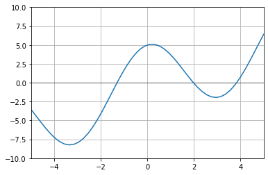

```python
#Importerer nødvendige pakker
from scipy.optimize import fsolve
import numpy as np
import matplotlib.pyplot as plt

#Definerer funksjonen som angir venstresiden i likninga f(x)=0
#som skal løses; her 5cos(x)+x = 0
def f(x):
    return 5*np.cos(x) + x

#Tegner funksjonen for å få et bilde av løsningene:
t=np.linspace(-5,5)
plt.axis([-5,5,-10,10])
plt.grid()
plt.axhline(color='black', lw=0.5)
plt.plot(t,f(t))
plt.show()
```

```python
#Ser løsninger i nærheten av x=-1; x=2
start = -1
sol = fsolve(f, start)
print("Løsning i nærheten av x=-1: ",sol[0])

start = 2
sol = fsolve(f, start)
print("Løsning i nærheten av x=2: ",sol[0])
```

```
Løsning i nærheten av x=-1:  -1.306440008369511
Løsning i nærheten av x=2:  1.977383029328841
```

## Oppgave 6 Refleksjonsoppgave

a) Hvilke oppgaver opplevde du som vanskelig?

b) Hva bør faglærer ta opp i neste time?